# The Wine Vinho Verde

Andresa de Andrade

April 2, 2015

# Exploratory Analysis

```r
#reading data
data<-read.csv("winequality-red.csv", sep=";")


#Treating data names to look preety in our charts/analysis

data_names<-names(data)

simpleCap <- function(x) {

  s <- strsplit(x, " ")[[1]]
  paste(toupper(substring(s, 1,1)), substring(s, 2),
        sep="", collapse=" ")
}

data_names<-as.vector(sapply(data_names, gsub, pattern="[.]", replacement = " "))
data_names<-as.vector(sapply(data_names, simpleCap))
#####################

num_variables = length(data)-1
```

It’s interesting to understand if the data set has any outliers or even missing information. Because, if positive, it’d be necessary some treatment prior to the data exploration.

Based on histograms in the appendix section, it’s possible to infer that the data set has some outliers affecting the model performance (and it has no missing values). For learning purposes, the data will be used as it’s and the influence of outliers will be bring up later on this document.

This is how the output variable behaviors:

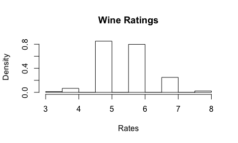

Histogram of Quality of Wine

```r
hist(data$quality, main = "Wine Ratings", xlab= "Rates", freq=F)
```

It’s noticeable that the majority of the grades are between 5 and 6 but it’s also possible to observe that the rates are slightly skewed to 7 due the heavy tail.

The question is what is relevant for the wine to be highly rated.

To try to answer this question, it’s necessary to go back to the (cor)relation between the grades and wine characteristics described in the data set.

## Sulfur Dioxide

Let’s start by the Sulfur Dioxide SO<sub>2</sub>. This substance has two main properties within the wine making process. First is to preserve the wine, preventing from oxidation. The second is to bind the acetaldehyde, since this last one has an unpleasant smell of bruised apple or rank sherry and it could affect the final taste of the wine.

In the data set there are two variables dedicated to SO<sub>2</sub>, one is called free sulfur dioxide and is a natural result of fermentation. And the other is Total Sulfur Dioxide being the result of the sum of free SO<sub>2</sub> and the level manually added.

This is a good example of a pair of variable that might be correlated and could be aggregate in a single one.

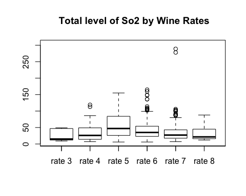

Box plot of Level of Sulfur Dioxide by rating

```r
#function that calculate the boxplot by rate for an specific variable using column name as arg
byrate_hist<-function(x, label){
  boxplot_string = ""
  x_label<-array()

  for(grade in 1:10){
    first_graph<-paste("data[data$quality==",grade, ",]$",x)
    boxplot_string = paste(boxplot_string, first_graph, ",")
    x_label[grade]<-paste("rate", grade)
  }
  first_string <-paste(boxplot_string, "main = '", label, "by Wine Rates'")

  lim_sup<-eval(parse(text = paste("max(data$", x,")*1.05")))
  lim_inf<-eval(parse(text = paste("min(data$", x,")*0.95")))

  second_string = paste("boxplot(", first_string, ", ylim=c(", lim_inf, ",", lim_sup,"), xlim=c(2.5,8.5))")

  test<-eval(parse(text =second_string))
  axis(1, 1:10,x_label)

}

byrate_hist("total.sulfur.dioxide", "Total level of So2")
```

```r
#function that creates the summary table for a specific variable using index as arg
library(knitr)
create_summary_table<-function (x) {
  median_alc<-aggregate(data[,x], list(data$quality), median)
  mean_alc<-aggregate(data[,x], list(data$quality), mean)
  min_alc<-aggregate(data[,x], list(data$quality), min)
  max_alc<-aggregate(data[,x], list(data$quality), max)
  sd_alc<-aggregate(data[,x], list(data$quality), sd)
  summary_table<-data.frame(median_alc, mean_alc[,2], min_alc[,2], max_alc[,2], sd_alc[,2])
  return(summary_table)
}

summary_table<-create_summary_table(7)
names(summary_table)<-c("Rates", "Mean", "Median", "Min", "Max", "Standard Deviation")
knitr::kable(summary_table, caption = "Total Sulfur Dioxide Summary")
```

Total Sulfur Dioxide Summary

[output not shown]

Combining the Figure 2 and the Table 1 we can see that the range level of So<sub>2</sub> between 15 and 48 increases the likelihood of having high rates.

## Volatile Acidity

From the correlation table it’s also possible to see that Volatile Acidity is significant for the sensorial analysis of the wine.

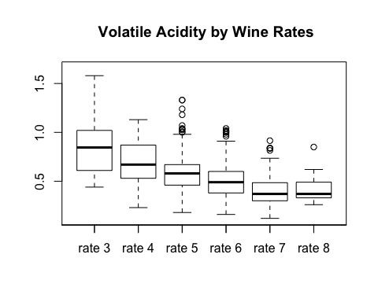

Level of Volatile Acidity

```r
byrate_hist("volatile.acidity", "Volatile Acidity")
```

```r
summary_table_alc<-create_summary_table(2)
names(summary_table_alc)<-c("Rates", "Mean", "Median", "Min", "Max", "Standard Deviation")
knitr::kable(summary_table_alc, caption = "Vol Acidity Summary")
```

Vol Acidity Summary

[output not shown]

## Alcohol

From the appendix section the other relevant substance is alcohol, the graphic and table below describe the distribution of level of alcohol for different rates

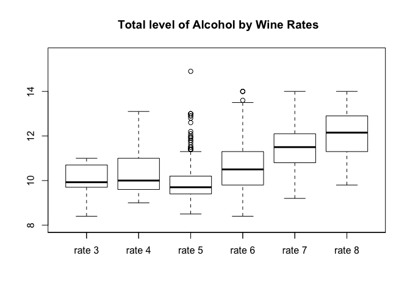

Total Level of alcohol

```r
byrate_hist("alcohol", "Total level of Alcohol")
```

```r
summary_table_alc<-create_summary_table(11)
names(summary_table_alc)<-c("Rates", "Mean", "Median", "Min", "Max", "Standard Deviation")
knitr::kable(summary_table_alc, caption = "Alcohol Summary")
```

Alcohol Summary

[output not shown]

# Correlation and PCA

## Correlation Analysis

It also confirms that the most important/relevant for high rates is alcohol, and volatile acidity has a negative effect in the wine quality.

At this point, it’s important to highlight that having a high correlation doesn’t mean having a causality.

```r
table_cor<-cor(data)
table_cor<-data.frame(table_cor)
names_cor<-c("Acid", "Vol.Acid", "Citr.Acid", "Sugar", "Chlor", "FreeSO2", "TotalSo2", "Den", "pH", "Sulph", "Alchool", "Qlity")
names(table_cor)<-names_cor
rownames(table_cor)<-names_cor
knitr::kable(table_cor, caption = "Correlation Matrix", digits = 2)
```

Correlation Matrix

|  | Acid | Vol.Acid | Citr.Acid | Sugar | Chlor | FreeSO2 | TotalSo2 | Den | pH | Sulph | Alchool | Qlity |
| --- | --- | --- | --- | --- | --- | --- | --- | --- | --- | --- | --- | --- |
| Acid | 1.00 | -0.26 | 0.67 | 0.11 | 0.09 | -0.15 | -0.11 | 0.67 | -0.68 | 0.18 | -0.06 | 0.12 |
| Vol.Acid | -0.26 | 1.00 | -0.55 | 0.00 | 0.06 | -0.01 | 0.08 | 0.02 | 0.23 | -0.26 | -0.20 | -0.39 |
| Citr.Acid | 0.67 | -0.55 | 1.00 | 0.14 | 0.20 | -0.06 | 0.04 | 0.36 | -0.54 | 0.31 | 0.11 | 0.23 |
| Sugar | 0.11 | 0.00 | 0.14 | 1.00 | 0.06 | 0.19 | 0.20 | 0.36 | -0.09 | 0.01 | 0.04 | 0.01 |
| Chlor | 0.09 | 0.06 | 0.20 | 0.06 | 1.00 | 0.01 | 0.05 | 0.20 | -0.27 | 0.37 | -0.22 | -0.13 |
| FreeSO2 | -0.15 | -0.01 | -0.06 | 0.19 | 0.01 | 1.00 | 0.67 | -0.02 | 0.07 | 0.05 | -0.07 | -0.05 |
| TotalSo2 | -0.11 | 0.08 | 0.04 | 0.20 | 0.05 | 0.67 | 1.00 | 0.07 | -0.07 | 0.04 | -0.21 | -0.19 |
| Den | 0.67 | 0.02 | 0.36 | 0.36 | 0.20 | -0.02 | 0.07 | 1.00 | -0.34 | 0.15 | -0.50 | -0.17 |
| pH | -0.68 | 0.23 | -0.54 | -0.09 | -0.27 | 0.07 | -0.07 | -0.34 | 1.00 | -0.20 | 0.21 | -0.06 |
| Sulph | 0.18 | -0.26 | 0.31 | 0.01 | 0.37 | 0.05 | 0.04 | 0.15 | -0.20 | 1.00 | 0.09 | 0.25 |
| Alchool | -0.06 | -0.20 | 0.11 | 0.04 | -0.22 | -0.07 | -0.21 | -0.50 | 0.21 | 0.09 | 1.00 | 0.48 |
| Qlity | 0.12 | -0.39 | 0.23 | 0.01 | -0.13 | -0.05 | -0.19 | -0.17 | -0.06 | 0.25 | 0.48 | 1.00 |

we can see from the table above some interesting highlights. The first one is that we were right about the correlation between Free SO<sub>2</sub> and Total So<sub>2</sub> variables, hence we might combined them in one single variable.

## Principal Component Analysis

The application of Principal Component only depends on the data covariance (or correlation) matrix, ie, it’s not necessary to assume any distribution for the data. Which makes the methodology much easier to use since there’s no assumption for the data distribution.

The graphic below shows the main components for the explanation of the variance. The table is built to carry the heaviest proportion of the variance in the first components.

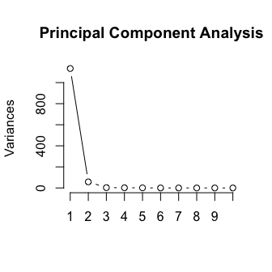

Proportion of Variance Explained by Principal Component

```r
pca <- prcomp(data[,1:11])
plot(pca, type ="l", main = "Principal Component Analysis")
```

```r
#summary(pca)
```

```r
summary_pca<-summary(pca)

percent <- function(x, digits = 2, format = "f", ...) {
  paste0(formatC(100 * x, format = format, digits = digits, ...), "%")
}
t1<-percent(summary_pca$importance[2,])
t2<-percent(summary_pca$importance[3,])
variance_pca<-cbind(t1,t2)
colnames(variance_pca)<-c("PVE", "Accumulated PVE")
rnames<-array()
for(i in 1:11){
  rnames[i]<-paste("PC",i, sep = "")
}

rownames(variance_pca)<-rnames
variance_pca<-data.frame(variance_pca)

knitr::kable(variance_pca, caption = "Proportion of Variance Explained by Components")
```

Proportion of Variance Explained by Components

|  | PVE | Accumulated.PVE |
| --- | --- | --- |
| PC1 | 94.66% | 94.66% |
| PC2 | 4.84% | 99.50% |
| PC3 | 0.26% | 99.75% |
| PC4 | 0.15% | 99.91% |
| PC5 | 0.09% | 99.99% |
| PC6 | 0.00% | 100.00% |
| PC7 | 0.00% | 100.00% |
| PC8 | 0.00% | 100.00% |
| PC9 | 0.00% | 100.00% |
| PC10 | 0.00% | 100.00% |
| PC11 | 0.00% | 100.00% |

The criteria to evaluate a good model is around 80 being good and greater than 99.5 being excellent, it’s important to mention that as the variance, the PVE can variate with the problem. For this project we will consider the first 3 component which consolidates 99.7% of the variance of our variables. The reason that we reduced the number of variables from 11 to 3 is because the data set has a high correlation, therefore it doesn’t vary or it has the same variation.

Besides reducing the number of variables for the model, the component also highlights any particular evidence for clusters.

```r
eigenvalues<-round(pca$sdev,2)
names<-data_names[1:11]
eigenvalues<-cbind(names, eigenvalues)
eigenvalues<-data.frame(eigenvalues)
names(eigenvalues)<-c("a", "b")
eigenvalues<-eigenvalues[with(eigenvalues, order(b)),]
names(eigenvalues)<-c("Variables", "EigenValues")
knitr::kable(eigenvalues, caption = "Eigenvalues", digits=2)
```

Eigenvalues

|  | Variables | EigenValues |
| --- | --- | --- |
| 11 | Alcohol | 0 |
| 10 | Sulphates | 0.04 |
| 9 | PH | 0.1 |
| 8 | Density | 0.11 |
| 7 | Total Sulfur Dioxide | 0.15 |
| 6 | Free Sulfur Dioxide | 0.2 |
| 5 | Chlorides | 1.02 |
| 4 | Residual Sugar | 1.35 |
| 3 | Citric Acid | 1.76 |
| 1 | Fixed Acidity | 33.67 |
| 2 | Volatile Acidity | 7.61 |

Based on eigenvalues we can observe that Acidity is more mixed within the rates in a way that most of the variability of the model are in these two variables.

```r
library(lattice)
library(directlabels)
```

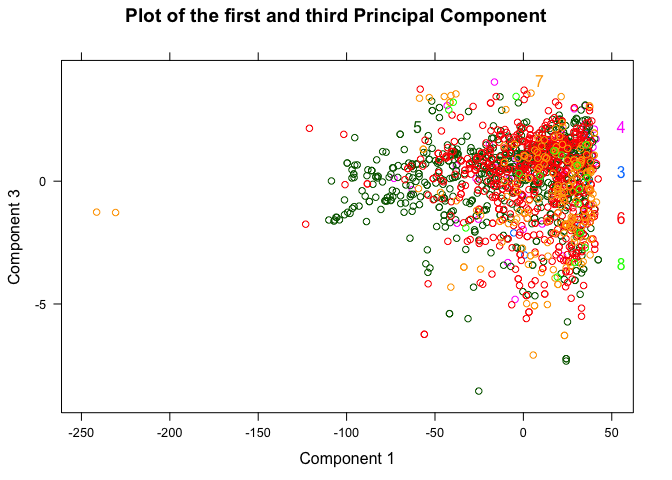

```r
t2<-cbind(pca$x[,1], pca$x[,3], data$quality)
direct.label(xyplot(t2[,2]~t2[,1],groups=t2[,3], ylab="Component 3", xlab = "Component 1", main = "Plot of the first and third Principal Component"))
```

We can see that the 5 rates is lower but also more expanded than the others.

# Classification Model

The classification methodology that we’ll be using in this document is the Logistic Regression. The reason we chose this model rather than the other classification methodologies is because this method shares the properties of all other memory-based classification methods - defer most of the processing of the training data point until after a query is made - and has some particular qualities like simplicity, capability of extrapolating and a known confidence interval.

```r
data_2<-data
data_2[,12]<-as.factor(data_2[,12])

formula_text <- paste(names(data_2[12]),"~",paste(names(data[1:11]), collapse="+"))
formula_raw <- as.formula(formula_text)
fit <- glm(formula_raw,data=data_2,family=binomial())
summary(fit)
```

```
##
## Call:
## glm(formula = formula_raw, family = binomial(), data = data_2)
##
## Deviance Residuals:
##      Min        1Q    Median        3Q       Max
## -2.96787   0.00752   0.02341   0.05730   1.22446
##
## Coefficients:
##                        Estimate Std. Error z value Pr(>|z|)
## (Intercept)           494.89510  523.99352   0.944 0.344931
## fixed.acidity          -0.28791    0.67009  -0.430 0.667446
## volatile.acidity       -8.40765    2.50988  -3.350 0.000809 ***
## citric.acid            -3.70698    3.92708  -0.944 0.345195
## residual.sugar          0.14205    0.29387   0.483 0.628827
## chlorides             -13.03262    7.00680  -1.860 0.062886 .
## free.sulfur.dioxide    -0.15367    0.08888  -1.729 0.083823 .
## total.sulfur.dioxide    0.09925    0.04981   1.992 0.046322 *
## density              -470.45027  533.58716  -0.882 0.377953
## pH                     -8.01302    4.80305  -1.668 0.095253 .
## sulphates               2.69403    3.47425   0.775 0.438088
## alcohol                 1.32310    0.77934   1.698 0.089563 .
## ---
## Signif. codes:  0 '***' 0.001 '**' 0.01 '*' 0.05 '.' 0.1 ' ' 1
##
## (Dispersion parameter for binomial family taken to be 1)
##
##     Null deviance: 121.428  on 1598  degrees of freedom
## Residual deviance:  69.165  on 1587  degrees of freedom
## AIC: 93.165
##
## Number of Fisher Scoring iterations: 10
```

Now applying the same methodology to the PCA data set we have the following output:

```r
data_pca<-cbind(pca$x[,1], pca$x[,2], pca$x[,3], data$quality)
data_pca<-data.frame(data_pca)
names(data_pca)<-c("comp1", "comp2", "comp3", "quality")
data_pca[,4]<-as.factor(data_pca[,4])

formula_text <- paste(names(data_pca[4]),"~",paste(names(data_pca[1:3]), collapse="+"))
formula <- as.formula(formula_text)
fit <- glm(formula,data=data_pca,family=binomial())
summary(fit)
```

```
##
## Call:
## glm(formula = formula, family = binomial(), data = data_pca)
##
## Deviance Residuals:
##     Min       1Q   Median       3Q      Max
## -3.4683   0.0580   0.1033   0.1417   0.1990
##
## Coefficients:
##             Estimate Std. Error z value Pr(>|z|)
## (Intercept)  5.76102    0.64052   8.994   <2e-16 ***
## comp1       -0.04768    0.02530  -1.885   0.0594 .
## comp2       -0.05441    0.07312  -0.744   0.4568
## comp3        0.01174    0.17916   0.066   0.9477
## ---
## Signif. codes:  0 '***' 0.001 '**' 0.01 '*' 0.05 '.' 0.1 ' ' 1
##
## (Dispersion parameter for binomial family taken to be 1)
##
##     Null deviance: 121.43  on 1598  degrees of freedom
## Residual deviance: 114.29  on 1595  degrees of freedom
## AIC: 122.29
##
## Number of Fisher Scoring iterations: 9
```

So Based on the table above only the the first component is relevant for the model, and as higher the value, the worse is the rating.

The only problem of having the pca model is the machine learning cost, because the algorithm would have to run the PCA and then using this “new data” we would have the logistic model. When we are dealing with huge data sets this becomes expansive.

## Machine Learning - 10 Cross Folder Validation

Now we need to run the cross validation for 10 folders. Based on the data below we can see that our model is very accurate. We have one loop with 3 prediction error over 67%

But still very accurate.

```r
library("caret")
set.seed(1)
folds <- createFolds(data$quality)
i=1
for (f in folds){
  train <- data[-f,]
  test <- data[f,]
  fit <- lm(formula_raw, data=train)
  test$scores <- predict(fit, type="response",
                      newdata=test)
  pred<-abs((round(test$scores)-test$quality)/test$quality)

  pred_table<-table(round(pred,2))
  print(paste("Prediction Table for validation", i))
  print(pred_table)

  #confusion matrix using 90% accuracy
  c<-table(factor(round(test$scores),levels=3:8), test$quality)
  print(paste("Confusion Matrix for validation", i))
  print(c)
  i=i+1
  }
```

```
## [1] "Prediction Table for validation 1"
##
##    0 0.14 0.17  0.2 0.25 0.33  0.4  0.5
##  101   14   22   14    5    1    1    1
## [1] "Confusion Matrix for validation 1"
##
##      3  4  5  6  7  8
##   3  0  0  0  0  0  0
##   4  1  0  0  0  0  0
##   5  0  3 54 21  0  0
##   6  0  1 14 41 14  2
##   7  0  0  1  1  6  0
##   8  0  0  0  0  0  0
## [1] "Prediction Table for validation 2"
##
```

[output cut: 115 more lines]

# Comparison to other models

# Conclusion

The computational cost for the algorithm is relatively low making possible the automation and deployment into a quality assurance process.

# Appendix

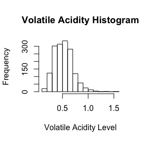

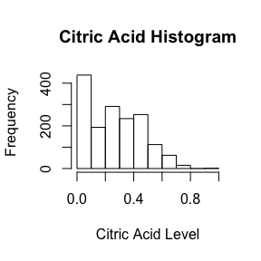

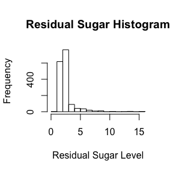

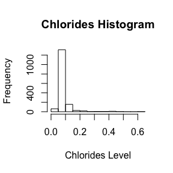

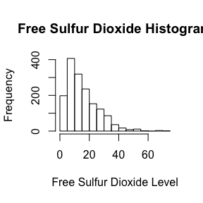

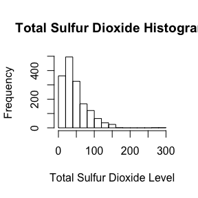

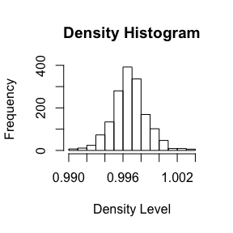

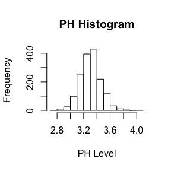

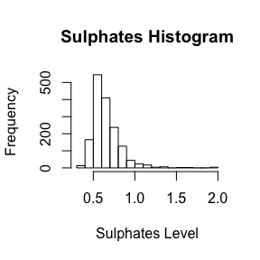

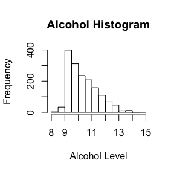

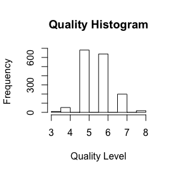